# Лабораторная работа №3

# Задания для самостоятельной работы

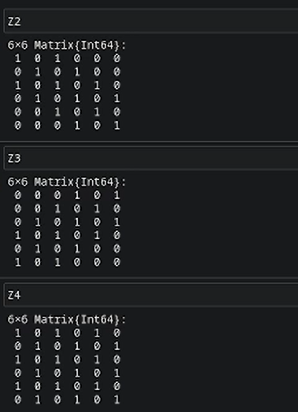

Рисунок 33: Задание 7 (продолжение)

# Задания для самостоятельной работы

8. В языке R есть функция outer(). Фактически, это матричное умножение с возможностью изменить применяемую операцию (например, заменить произведение на сложение или возведение в степень).

8.1. Напишите свою функцию, аналогичную функции outer() языка R.

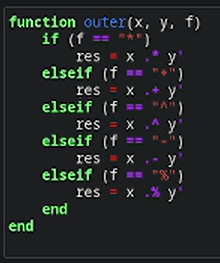

Рисунок 34: Задание 8.1

# Задания для самостоятельной работы

8.2. Используя написанную вами функцию outer(), создайте матрицы $A_1$, $A_2$, $A_3$, $A_4$, $A_5$.

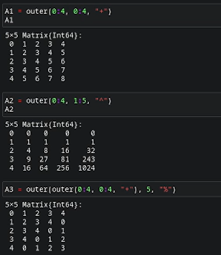

Рисунок 35: Задание 8.2

# Задания для самостоятельной работы

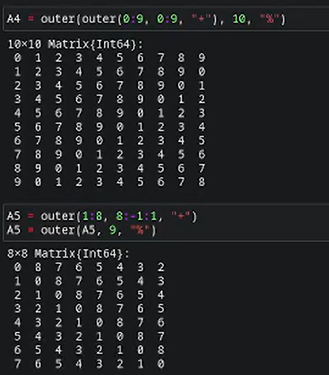

Рисунок 36: Задание 8.2 (продолжение)

# Задания для самостоятельной работы

9. Решите систему линейных уравнений с 5 неизвестными.

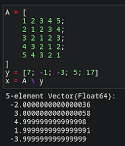

Рисунок 37: Задание 9

# Задания для самостоятельной работы

10. Создайте матрицу $M$ размерности $6 \times 10$, элементами которой являются целые числа, выбранные случайным образом с повторениями из совокупности $1, 2, \dots , 10$.

10.1. Найдите число элементов в каждой строке матрицы $M$, которые больше числа $N$ (например, $N = 4$).

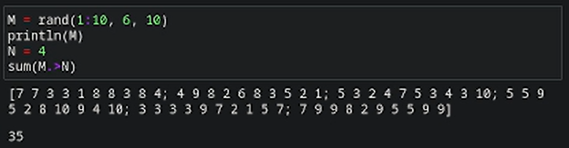

Рисунок 38: Задание 10.1

# Задания для самостоятельной работы

10.2. Определите, в каких строках матрицы $M$ число $M$ (например, $M = 7$) встречается ровно 2 раза?

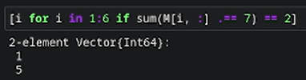

Рисунок 39: Задание 10.2

# Задания для самостоятельной работы

10.3. Определите все пары столбцов матрицы $M$, сумма элементов которых больше $K$ (например, $K = 75$).

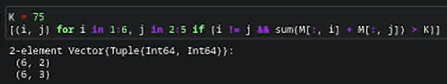

Рисунок 40: Задание 10.3

# Задания для самостоятельной работы

11. Вычислите суммы.

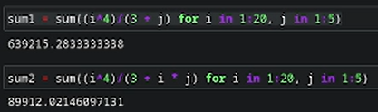

Рисунок 41: Задание 11

# Выводы

Освоено применение циклов, функций и сторонних для Julia пакетов для решения задач линейной алгебры и работы с матрицами.